# Analysis

## Data

#### System Data

Where do Citi Bikers ride? When do they ride? How far do they go? Which stations are most popular? What days of the week are most rides taken on? We've heard all of these questions and more from you, and we're happy to provide the data to help you discover the answers to these questions and more. We invite developers, engineers, statisticians, artists, academics and other interested members of the public to use the data we provide for analysis, development, visualization and whatever else moves you. (text, dataset from: https://ride.citibikenyc.com/system-data)

Data analyzed in this notebook: https://s3.amazonaws.com/tripdata/201406-citibike-tripdata.zip

- Note: unarchive data and save csv file into input_data\2014-06_citi_bike_trip_data.csv

```python
import pandas as pd
from IPython.display import display, HTML
import os
import numpy as np

input_name            = "2014-06_citi_bike_trip_data.csv"
data                  = pd.read_csv(os.path.join("input_data", input_name))

PLOT_SIZE = (16,8)
YEAR      = int(input_name.split("-")[0])

#get rid of spaces
data.columns = data.columns.str.replace(" ", "_")

#convert timestamps
data["startdatetime"] = pd.to_datetime(data["starttime"], format='%Y-%m-%d %H:%M:%S.%f')
data["stopdatetime"]  = pd.to_datetime(data["stoptime"],  format='%Y-%m-%d %H:%M:%S.%f')

display(data)
data.describe()
```

|  | tripduration | starttime | stoptime | start_station_id | start_station_name | start_station_latitude | start_station_longitude | end_station_id | end_station_name | end_station_latitude | end_station_longitude | bikeid | usertype | birth_year | gender | startdatetime | stopdatetime |
| --- | --- | --- | --- | --- | --- | --- | --- | --- | --- | --- | --- | --- | --- | --- | --- | --- | --- |
| 0 | 520 | 2014-06-01 00:00:02 | 2014-06-01 00:08:42 | 358 | Christopher St & Greenwich St | 40.732916 | -74.007114 | 426 | West St & Chambers St | 40.717548 | -74.013221 | 18840 | Subscriber | 1979 | 1 | 2014-06-01 00:00:02 | 2014-06-01 00:08:42 |
| 1 | 520 | 2014-06-01 00:00:27 | 2014-06-01 00:09:07 | 335 | Washington Pl & Broadway | 40.729039 | -73.994046 | 265 | Stanton St & Chrystie St | 40.722293 | -73.991475 | 17442 | Customer | \N | 0 | 2014-06-01 00:00:27 | 2014-06-01 00:09:07 |
| 2 | 414 | 2014-06-01 00:00:32 | 2014-06-01 00:07:26 | 439 | E 4 St & 2 Ave | 40.726281 | -73.989780 | 368 | Carmine St & 6 Ave | 40.730386 | -74.002150 | 16447 | Subscriber | 1980 | 1 | 2014-06-01 00:00:32 | 2014-06-01 00:07:26 |
| 3 | 310 | 2014-06-01 00:00:34 | 2014-06-01 00:05:44 | 463 | 9 Ave & W 16 St | 40.742065 | -74.004432 | 380 | W 4 St & 7 Ave S | 40.734011 | -74.002939 | 18218 | Subscriber | 1984 | 1 | 2014-06-01 00:00:34 | 2014-06-01 00:05:44 |
| 4 | 457 | 2014-06-01 00:00:35 | 2014-06-01 00:08:12 | 352 | W 56 St & 6 Ave | 40.763406 | -73.977225 | 305 | E 58 St & 3 Ave | 40.760958 | -73.967245 | 18115 | Subscriber | 1969 | 1 | 2014-06-01 00:00:35 | 2014-06-01 00:08:12 |
| ... | ... | ... | ... | ... | ... | ... | ... | ... | ... | ... | ... | ... | ... | ... | ... | ... | ... |
| 936875 | 1123 | 2014-06-30 23:59:18 | 2014-07-01 00:18:01 | 488 | W 39 St & 9 Ave | 40.756458 | -73.993722 | 284 | Greenwich Ave & 8 Ave | 40.739017 | -74.002638 | 17303 | Subscriber | 1980 | 1 | 2014-06-30 23:59:18 | 2014-07-01 00:18:01 |
| 936876 | 608 | 2014-06-30 23:59:22 | 2014-07-01 00:09:30 | 308 | St James Pl & Oliver St | 40.713079 | -73.998512 | 426 | West St & Chambers St | 40.717548 | -74.013221 | 19456 | Subscriber | 1979 | 2 | 2014-06-30 23:59:22 | 2014-07-01 00:09:30 |
| 936877 | 336 | 2014-06-30 23:59:30 | 2014-07-01 00:05:06 | 529 | W 42 St & 8 Ave | 40.757570 | -73.990985 | 449 | W 52 St & 9 Ave | 40.764618 | -73.987895 | 21109 | Subscriber | 1979 | 1 | 2014-06-30 23:59:30 | 2014-07-01 00:05:06 |
| 936878 | 1299 | 2014-06-30 23:59:50 | 2014-07-01 00:21:29 | 518 | E 39 St & 2 Ave | 40.747804 | -73.973442 | 356 | Bialystoker Pl & Delancey St | 40.716226 | -73.982612 | 20636 | Subscriber | 1988 | 1 | 2014-06-30 23:59:50 | 2014-07-01 00:21:29 |
| 936879 | 312 | 2014-06-30 23:59:50 | 2014-07-01 00:05:02 | 263 | Elizabeth St & Hester St | 40.717290 | -73.996375 | 250 | Lafayette St & Jersey St | 40.724561 | -73.995653 | 20951 | Subscriber | 1970 | 1 | 2014-06-30 23:59:50 | 2014-07-01 00:05:02 |

936880 rows × 17 columns

|  | tripduration | start_station_id | start_station_latitude | start_station_longitude | end_station_id | end_station_latitude | end_station_longitude | bikeid | gender |
| --- | --- | --- | --- | --- | --- | --- | --- | --- | --- |
| count | 936880.000000 | 936880.000000 | 936880.000000 | 936880.000000 | 936880.000000 | 936880.000000 | 936880.000000 | 936880.000000 | 936880.000000 |
| mean | 892.240022 | 453.720084 | 40.734018 | -73.991431 | 452.848643 | 40.733643 | -73.991475 | 18156.610201 | 1.084565 |
| std | 919.055773 | 377.767545 | 0.019564 | 0.012439 | 378.026358 | 0.019586 | 0.012559 | 2106.789609 | 0.574513 |
| min | 60.000000 | 72.000000 | 40.680342 | -74.017134 | 72.000000 | 40.680342 | -74.017134 | 14529.000000 | 0.000000 |
| 25% | 417.000000 | 306.000000 | 40.720434 | -74.001497 | 305.000000 | 40.720196 | -74.001547 | 16335.000000 | 1.000000 |
| 50% | 673.000000 | 403.000000 | 40.735354 | -73.991255 | 402.000000 | 40.735238 | -73.991255 | 18161.000000 | 1.000000 |
| 75% | 1112.000000 | 489.000000 | 40.749156 | -73.982681 | 488.000000 | 40.748901 | -73.982612 | 19969.000000 | 1.000000 |
| max | 21576.000000 | 3002.000000 | 40.771522 | -73.953809 | 3002.000000 | 40.771522 | -73.953809 | 21684.000000 | 2.000000 |

## When do they ride?

The following graph shows how hours are exposed during a day. Timestamps are streamlined to hours of ride start or end.

Blue and Orange lines do not represent the average count of how many bikes are ridden in any given hour, but the usual times of beginnings and ends of rides. Real hours driven are represented as Green line. As we can see, in morning and evening, real hours and starting hours stick together firmly. We can see line separation between 11 a.m. and 6 p.m. So that implies that in this time people tend to go on longer drives.

```
Number of drives longer than 1 hour is 10938 from total of 936880 drives (1.167%).
```

[output not shown]

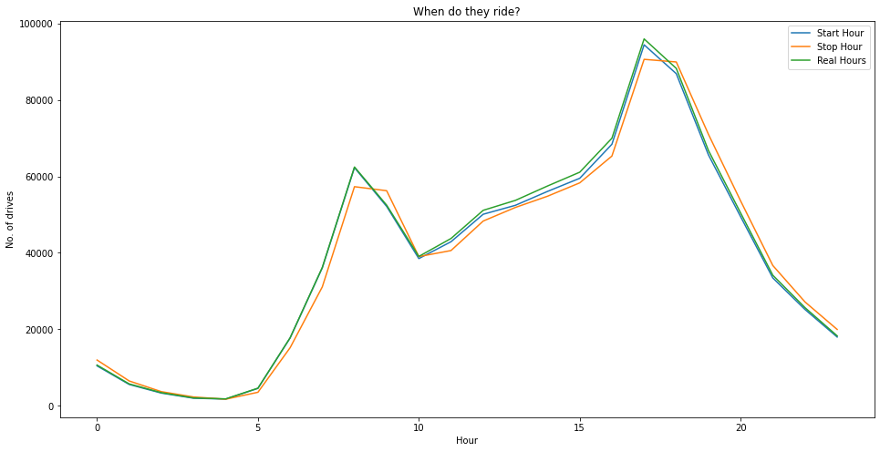

```python
data["starthour"] = data["startdatetime"].dt.hour
data["stophour"]  = data["stopdatetime"].dt.hour

df = pd.DataFrame({"Start Hour":data.groupby(["starthour"]).size(), "Stop Hour":data.groupby(["stophour"]).size()})

driven_hours = [0 for i in range(24)]

import datetime
from dateutil import rrule

drives_longer_then_hour = 0

for start, stop in zip(data.startdatetime, data.stopdatetime):
    for index, dt in enumerate(rrule.rrule(rrule.HOURLY, dtstart=start, until=stop)):
        driven_hours[dt.hour] += 1
        if index == 1:
            drives_longer_then_hour += 1

drives_longer_then_hour_perc = 100.0*drives_longer_then_hour/len(data.index)
print(f"Number of drives longer than 1 hour is {drives_longer_then_hour} from total of {len(data.index)} drives ({drives_longer_then_hour_perc:0.3f}%).")

df["Real Hours"] = driven_hours

pl = df.plot(legend=True,kind="line", figsize=PLOT_SIZE)
pl.set(xlabel="Hour", ylabel="No. of drives", title="When do they ride?")
```

## What days of the week are most rides taken on?

The following graph shows how days of the week are exposed.

Only starting day of the ride is taken into consideration.

[output not shown]

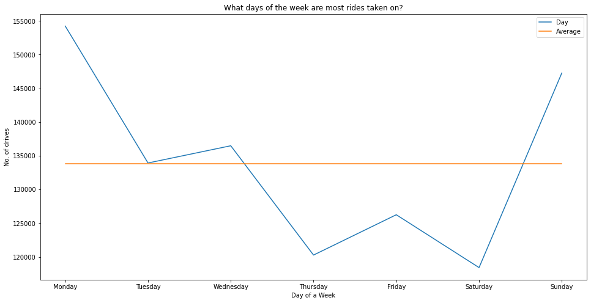

```python
day_names        = [ 'Monday', 'Tuesday', 'Wednesday', 'Thursday', 'Friday', 'Saturday', 'Sunday']
data["startday"] = data["startdatetime"].dt.day_name()

df = pd.DataFrame({"Day":data.groupby(["startday"]).size(), "Average":data.groupby(["startday"]).size().mean()}).reindex(day_names)
pl = df.plot(legend=True, kind="line", figsize=PLOT_SIZE)

pl.set(xlabel="Day of a Week", ylabel="No. of drives", title="What days of the week are most rides taken on?")
```

## Which stations are most popular?

The following graph shows the 10 most used stations to start or end the ride.

[output not shown]

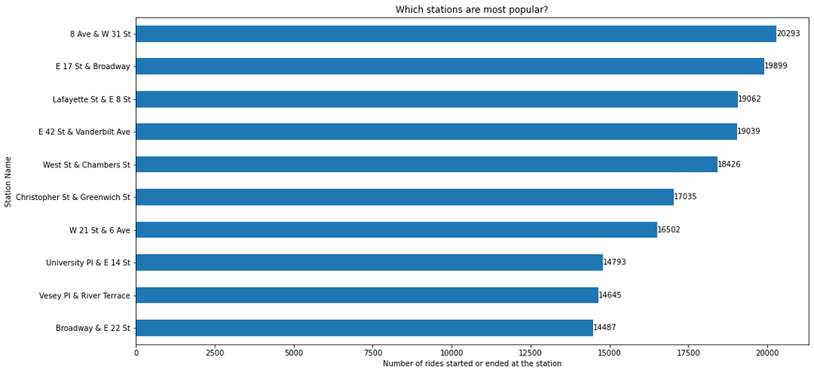

```python
df = pd.DataFrame()
df = data.groupby(["start_station_name"]).size() + data.groupby(["end_station_name"]).size()
df = df.sort_values(ascending=False)
pl = df.head(n=10).sort_values(ascending=True).plot(legend=False, kind="barh", figsize=PLOT_SIZE)

pl.bar_label(pl.containers[0])
pl.set(xlabel="Number of rides started or ended at the station", ylabel="Station Name", title="Which stations are most popular?")
```

## How far do Citi Bikers go?

The following graph shows the histogram of all rides distances with a resolution of 100m.

Ride distance is computed as the great circle distance between the start and end station.

```
array([[<AxesSubplot:title={'center':'distance'}>]], dtype=object)
```

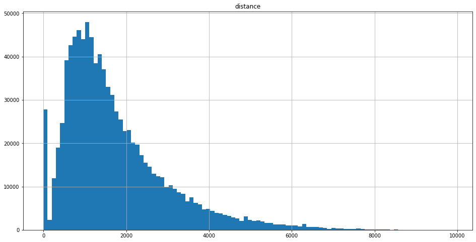

```python
from geopy.distance import great_circle

HIST_RESOLUTION = 100 #meters

def get_distance(lat1:float, lon1:float, lat2:float, lon2:float) -> float:
    """Calculate great circle distance between two points.

    Args:
        lat1(float): Point 1 latitude.
        lon1(float): Point 1 longitude.
        lat2(float): Point 2 latitude.
        lon2(float): Point 2 longitude.
    """
    coordinates_from = (lat1, lon1)
    coordinates_to   = (lat2, lon2)
    return great_circle(coordinates_from, coordinates_to).meters

data["distance"] = data[["start_station_latitude", "start_station_longitude","end_station_latitude", "end_station_longitude"]].apply(lambda x: get_distance(*x), axis=1)

data.hist(column="distance", bins=int(data["distance"].max()/HIST_RESOLUTION), figsize=PLOT_SIZE)
```

## Where do Citi Bikers ride?

Blue lines on map background are cycle roads.

Map source: https://www.openstreetmap.org/#map=12/40.7115/-74.0341&layers=C

```
                   station_name  visits   latitude  longitude
0               8 Ave & W 31 St   20293  40.732916 -74.007114
1            E 17 St & Broadway   19899  40.729039 -73.994046
2         Lafayette St & E 8 St   19062  40.726281 -73.989780
3      E 42 St & Vanderbilt Ave   19039  40.742065 -74.004432
4         West St & Chambers St   18426  40.763406 -73.977225
..                          ...     ...        ...        ...
323     Monroe St & Classon Ave     540  40.700469 -73.991454
324  Hanover Pl & Livingston St     436  40.734927 -73.992005
325    Park Ave & St Edwards St     314  40.700469 -73.991454
326          Sands St & Navy St     285  40.728419 -73.987140
327      Railroad Ave & Kay Ave     249  40.736197 -74.008592

[328 rows x 4 columns]
```

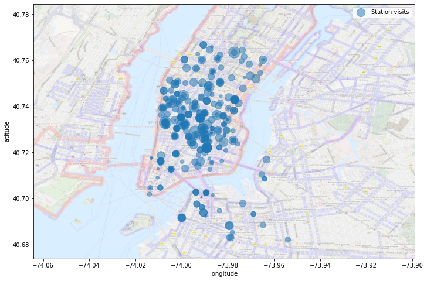

```python
import matplotlib.pyplot as plt
import matplotlib.image as mpimg

df               = pd.DataFrame()
df               = data.groupby(["start_station_name"]).size() + data.groupby(["end_station_name"]).size()
stations         = df.sort_values(ascending=False)

stations         = stations.reset_index()
#rename 2 columns from groupby selection
stations.columns = ["station_name", "visits"]
#prepare list of columns to be droped after concatenate dataframes
columns_to_rem   = list(data.columns)
columns_to_rem.remove("start_station_latitude")
columns_to_rem.remove("start_station_longitude")
#concatenate dataframes, drop unused columns, drop start_station_ prefix
stations         = pd.concat([stations, data.reindex(stations.index)], axis=1)
stations         = stations.drop(columns=columns_to_rem)
stations.columns = stations.columns.str.replace("start_station_", "")

print(stations)

nyc_image        = mpimg.imread("nyc.png")

stations.plot(kind="scatter", x="longitude", y="latitude",
    s=stations["visits"]/50, label="Station visits", alpha=0.5, figsize=PLOT_SIZE,
)
plt.imshow(nyc_image, extent=[-74.0643, -73.8991, 40.6739, 40.7844], alpha=0.5)
plt.legend()
plt.show()
```

## EXTRA: What is subscriber percentage?

The following pie chart shows the distribution of Citi Bikers subscribers.

```
[Text(0.5, 1.0, 'What is subscriber percentage?'), Text(0, 0.5, '')]
```

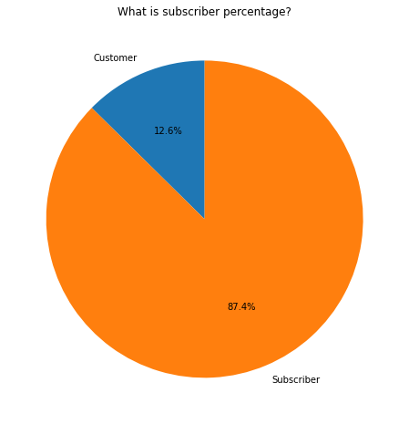

```python
df = pd.DataFrame()
df = data.groupby(["usertype"]).size()
pl = df.plot(kind="pie", startangle=90, autopct="%1.1f%%", figsize=PLOT_SIZE)
pl.set(title="What is subscriber percentage?", ylabel="")
```

## EXTRA: What is age of Male and Female cyclists?

The following histogram overlays age of Male and Female cyclists registered as Citi Bikers subscribers.

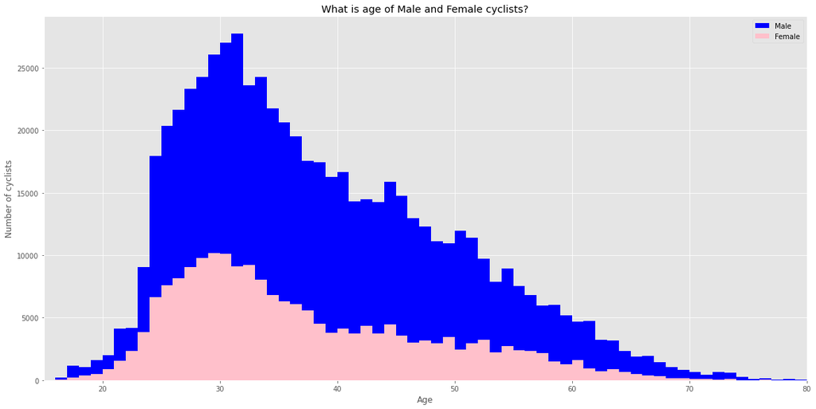

```python
data["birth_year"] = pd.to_numeric(data["birth_year"], errors='coerce')
data["age"]        = YEAR - data["birth_year"]
df   = data[data["usertype"] == "Subscriber"]
df_m = data[data["gender"] == 1]
df_f = data[data["gender"] == 2]


pltf = plt.figure(figsize=PLOT_SIZE)
plt.style.use('ggplot')
plt.title('What are age of Male and Female cyclists?')
plt.hist(df_m["age"], bins=int(data["age"].max()-data["age"].min()), color="Blue", label="Male")
plt.hist(df_f["age"], bins=int(data["age"].max()-data["age"].min()), color="Pink", label="Female")
plt.tight_layout()
plt.title("What is age of Male and Female cyclists?")
plt.xlabel('Age')
plt.ylabel('Number of cyclists')
plt.xlim([15, 80])
plt.legend()
plt.show()
```